# Regional correlation structure and expression magnitude along the Inv4m introgression

FV Rodriguez

# Overview

This notebook examines how expression correlation and fold change magnitude vary along the Inv4m introgression on chromosome 4. Three questions:

1. **Inter-regional correlation:** Do DEGs inside Inv4m correlate more or less strongly with DEGs outside the introgression than flanking DEGs do?
2. **Intra-regional correlation:** How tightly are DEGs co-regulated within each region (inv4m, flanking, outside)?
3. **Sliding window patterns:** How do correlation with outside DEGs and fold change magnitude vary along the physical map?

# Setup

```r
library(here)
library(dplyr)
library(ggplot2)
library(zoo)
library(tidyr)

source(here("scripts", "utils", "setup_paths.R"))
paths <- setup_project_paths("inversion_paper")
```

```r
effects_df <- read.csv(
  file.path(paths$intermediate, "predictor_effects_leaf_interaction_model.csv")
) %>%
  filter(predictor == "Inv4m")

nrow(effects_df)
```

```
## [1] 24011
```

```r
effects_df$P <- effects_df$P.Value
effects_df$neglogP <- -log10(effects_df$P)

xp <- readRDS(file.path(paths$intermediate, "normalized_expression_logCPM_leaf_trt.rds"))
```

```r
# Remap column names to match the original analysis
# DE script uses: in_Inv4m, in_cis (shared introgression), in_flank, in_trans
# Add convenience columns
effects_df <- effects_df %>%
  mutate(
    in_inv4m = in_Inv4m,
    in_flanking = in_flank,
    in_shared = in_cis,
    region = case_when(
      in_Inv4m ~ "inv4m",
      in_flank ~ "flanking",
      TRUE ~ "outside"
    ),
    is_significant = adj.P.Val < 0.05
  )

bonferroni_threshold <- 0.05 / nrow(effects_df)
```

# DEG lists by region

Identify Bonferroni-significant DEGs in each region, removing duplicated gene names (e.g., JMJ paralogs mapped to the same locus label).

```r
inv4_inv4 <- effects_df$gene[effects_df$P < bonferroni_threshold & effects_df$in_inv4m] %>%
  sort() %>% unique()

inv4_flanking <- effects_df$gene[effects_df$P < bonferroni_threshold & effects_df$in_flanking] %>%
  sort() %>% unique()

inv4_outside <- effects_df$gene[effects_df$P < bonferroni_threshold & !effects_df$in_shared] %>%
  sort() %>% unique()

inv4_introgression <- effects_df$gene[effects_df$P < bonferroni_threshold & effects_df$in_shared] %>%
  sort() %>% unique()

cat("DEGs by region (Bonferroni):\n")
```

```
## DEGs by region (Bonferroni):
```

```r
cat("  Inv4m:", length(inv4_inv4), "\n")
```

```
##   Inv4m: 63
```

```r
cat("  Flanking:", length(inv4_flanking), "\n")
```

```
##   Flanking: 91
```

```r
cat("  Outside:", length(inv4_outside), "\n")
```

```
##   Outside: 36
```

```r
cat("  Total introgression:", length(inv4_introgression), "\n")
```

```
##   Total introgression: 154
```

# Inter-regional correlations (DEGs vs outside DEGs)

Compute pairwise expression correlations between outside DEGs and DEGs inside Inv4m or in the flanking region. This tests whether genes in one region of the introgression are more tightly co-regulated with the rest of the genome than genes in the other region.

```r
out_inv4m <- cor(t(xp[inv4_outside, ]), t(xp[inv4_inv4, ]))
out_flanking <- cor(t(xp[inv4_outside, ]), t(xp[inv4_flanking, ]))
out_introgression <- cor(t(xp[inv4_outside, ]), t(xp[inv4_introgression, ]))

cat("Correlation matrix dimensions:\n")
```

```
## Correlation matrix dimensions:
```

```r
cat("  Outside x Inv4m:", paste(dim(out_inv4m), collapse = " x "), "\n")
```

```
##   Outside x Inv4m: 36 x 63
```

```r
cat("  Outside x Flanking:", paste(dim(out_flanking), collapse = " x "), "\n")
```

```
##   Outside x Flanking: 36 x 91
```

```r
cat("  Outside x Introgression:", paste(dim(out_introgression), collapse = " x "), "\n")
```

```
##   Outside x Introgression: 36 x 154
```

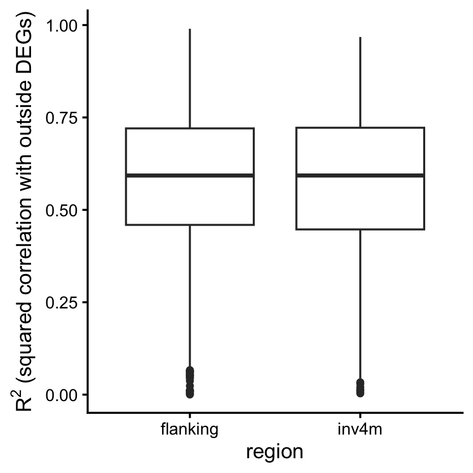

```r
to_plot <- rbind(
  data.frame(region = "inv4m", cor = as.numeric(out_inv4m)),
  data.frame(region = "flanking", cor = as.numeric(out_flanking))
)
to_plot$R2 <- to_plot$cor^2

to_plot %>%
  ggplot(aes(x = region, y = R2)) +
  geom_boxplot() +
  ylab(expression(R^2 ~ "(squared correlation with outside DEGs)")) +
  ggpubr::theme_classic2(base_size = 16)
```

```r
cat("=== R2 ~ region (all correlations) ===\n")
```

```
## === R2 ~ region (all correlations) ===
```

```r
lm(R2 ~ region, data = to_plot) %>% summary() %>% print()
```

```
##
## Call:
## lm(formula = R2 ~ region, data = to_plot)
##
## Residuals:
##      Min       1Q   Median       3Q      Max
## -0.57945 -0.12469  0.01374  0.14120  0.41028
##
## Coefficients:
##              Estimate Std. Error t value Pr(>|t|)
## (Intercept)  0.579728   0.003350 173.076   <2e-16 ***
## regioninv4m -0.001084   0.005237  -0.207    0.836
## ---
## Signif. codes:  0 '***' 0.001 '**' 0.01 '*' 0.05 '.' 0.1 ' ' 1
##
## Residual standard error: 0.1917 on 5542 degrees of freedom
## Multiple R-squared:  7.725e-06,  Adjusted R-squared:  -0.0001727
## F-statistic: 0.04281 on 1 and 5542 DF,  p-value: 0.8361
```

```r
cat("\n=== R2 ~ region (negative correlations only) ===\n")
```

```
##
## === R2 ~ region (negative correlations only) ===
```

```r
lm(R2 ~ region, data = to_plot[to_plot$cor < 0, ]) %>% summary() %>% print()
```

```
##
## Call:
## lm(formula = R2 ~ region, data = to_plot[to_plot$cor < 0, ])
##
## Residuals:
##     Min      1Q  Median      3Q     Max
## -0.5902 -0.1351  0.0143  0.1582  0.3742
##
## Coefficients:
##             Estimate Std. Error t value Pr(>|t|)
## (Intercept) 0.585673   0.004742 123.510   <2e-16 ***
## regioninv4m 0.007842   0.007311   1.073    0.284
## ---
## Signif. codes:  0 '***' 0.001 '**' 0.01 '*' 0.05 '.' 0.1 ' ' 1
##
## Residual standard error: 0.2008 on 3093 degrees of freedom
## Multiple R-squared:  0.0003719,  Adjusted R-squared:  4.867e-05
## F-statistic: 1.151 on 1 and 3093 DF,  p-value: 0.2835
```

```r
cat("\n=== R2 ~ region (positive correlations only) ===\n")
```

```
##
## === R2 ~ region (positive correlations only) ===
```

```r
lm(R2 ~ region, data = to_plot[to_plot$cor > 0, ]) %>% summary() %>% print()
```

```
##
## Call:
## lm(formula = R2 ~ region, data = to_plot[to_plot$cor > 0, ])
##
## Residuals:
##      Min       1Q   Median       3Q      Max
## -0.57048 -0.11243  0.01308  0.12417  0.41746
##
## Coefficients:
##              Estimate Std. Error t value Pr(>|t|)
## (Intercept)  0.572542   0.004642 123.350   <2e-16 ***
## regioninv4m -0.013939   0.007390  -1.886   0.0594 .
## ---
## Signif. codes:  0 '***' 0.001 '**' 0.01 '*' 0.05 '.' 0.1 ' ' 1
##
## Residual standard error: 0.1787 on 2447 degrees of freedom
## Multiple R-squared:  0.001452,   Adjusted R-squared:  0.001044
## F-statistic: 3.557 on 1 and 2447 DF,  p-value: 0.0594
```

# Intra-regional correlations

How tightly co-regulated are DEGs within each region? Compute pairwise correlations within inv4m, flanking, and outside DEGs separately.

```r
inner_inv4m <- cor(t(xp[inv4_inv4, ]))
inner_flanking <- cor(t(xp[inv4_flanking, ]))
inner_outside <- cor(t(xp[inv4_outside, ]))

to_plot <- rbind(
  data.frame(
    comparison = "inv4m\noutside",
    cor = out_inv4m[upper.tri(out_inv4m, diag = FALSE)]
  ),
  data.frame(
    comparison = "flanking\noutside",
    cor = out_flanking[upper.tri(out_flanking, diag = FALSE)]
  ),
  data.frame(
    comparison = "inv4m\ninv4m",
    cor = inner_inv4m[upper.tri(inner_inv4m, diag = FALSE)]
  ),
  data.frame(
    comparison = "flanking\nflanking",
    cor = inner_flanking[upper.tri(inner_flanking, diag = FALSE)]
  ),
  data.frame(
    comparison = "outside\noutside",
    cor = inner_outside[upper.tri(inner_outside, diag = FALSE)]
  )
)

to_plot$R2 <- to_plot$cor^2
```

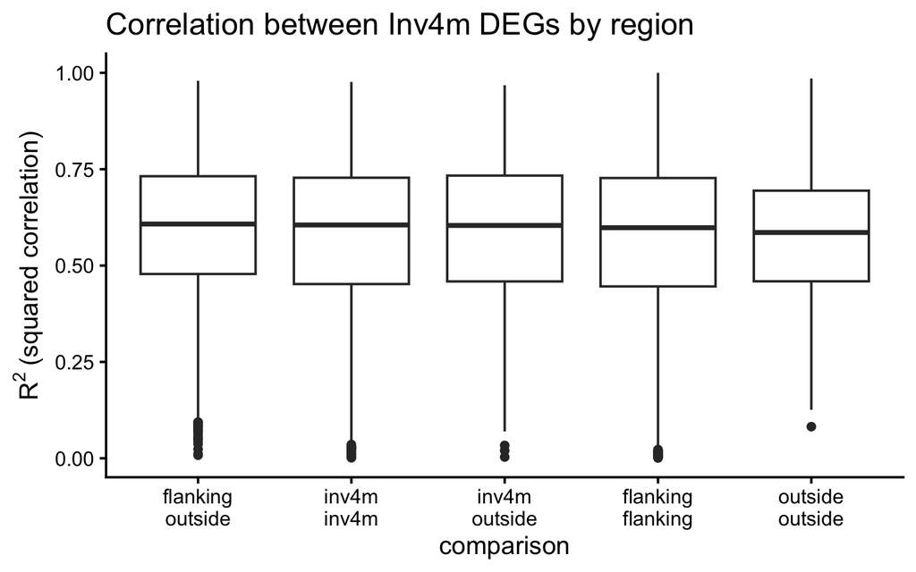

```r
to_plot %>%
  mutate(comparison = factor(comparison)) %>%
  mutate(comparison = forcats::fct_reorder(comparison, -R2)) %>%
  ggplot(aes(x = comparison, y = R2)) +
  ggtitle("Correlation between Inv4m DEGs by region") +
  ylab(expression(R^2 ~ "(squared correlation)")) +
  geom_boxplot() +
  ggpubr::theme_classic2(base_size = 16) +
  theme(legend.position = "none")
```

```r
lm(R2 ~ comparison, data = to_plot) %>% summary()
```

```
##
## Call:
## lm(formula = R2 ~ comparison, data = to_plot)
##
## Residuals:
##      Min       1Q   Median       3Q      Max
## -0.58814 -0.12483  0.01714  0.14575  0.42694
##
## Coefficients:
##                             Estimate Std. Error t value Pr(>|t|)
## (Intercept)                 0.573064   0.003024 189.521  < 2e-16 ***
## comparisonflanking\noutside 0.023088   0.004846   4.764 1.92e-06 ***
## comparisoninv4m\ninv4m      0.004948   0.005321   0.930  0.35248
## comparisoninv4m\noutside    0.018207   0.005702   3.193  0.00141 **
## comparisonoutside\noutside  0.013185   0.008281   1.592  0.11137
## ---
## Signif. codes:  0 '***' 0.001 '**' 0.01 '*' 0.05 '.' 0.1 ' ' 1
##
## Residual standard error: 0.1935 on 10885 degrees of freedom
## Multiple R-squared:  0.002498,   Adjusted R-squared:  0.002131
## F-statistic: 6.814 on 4 and 10885 DF,  p-value: 1.79e-05
```

# Sliding window: R² with outside DEGs along chromosome 4

For each 25-gene window along chromosome 4, compute the mean R² between genes in that window and all outside DEGs. This shows how the strength of trans-correlation varies along the introgression.

```r
in_out_cor <- t(out_introgression)
in_out_R2 <- in_out_cor^2

rollme <- cbind(
  data.frame(gene = unique(colnames(out_introgression))),
  as.data.frame(in_out_cor)
)

get_midelement <- function(vec) vec[ceiling(length(vec) / 2)]

r2 <- rollapply(
  rollme$gene,
  width = 25,
  function(x) mean(as.numeric(in_out_R2[x, ])),
  by.column = FALSE
)

mid_gene <- rollapply(
  rollme$gene,
  width = 25,
  function(x) get_midelement(x),
  by.column = FALSE
)

by_window <- data.frame(r2_win = r2, gene = mid_gene)
```

```r
# Derive boundaries from gene positions in the effects data
introgression_limit <- c(
  min(effects_df$BP[effects_df$in_shared]),
  max(effects_df$BP[effects_df$in_shared])
) / 1e6

inversion_limit <- c(
  min(effects_df$BP[effects_df$in_inv4m]),
  max(effects_df$BP[effects_df$in_inv4m])
) / 1e6
```

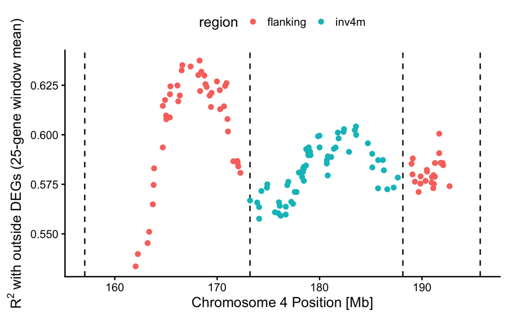

```r
to_plot <- effects_df %>%
  mutate(BP = BP / 1e6) %>%
  inner_join(by_window, by = "gene")

to_plot %>%
  ggplot(aes(x = BP, y = r2_win, col = region)) +
  geom_vline(
    xintercept = c(introgression_limit, inversion_limit),
    linetype = "dashed"
  ) +
  ylab(expression(R^2 ~ "with outside DEGs (25-gene window mean)")) +
  xlab("Chromosome 4 Position [Mb]") +
  geom_point() +
  ggpubr::theme_classic2(base_size = 16) +
  theme(legend.position = "top")
```

# Sliding window: fold change along chromosome 4

Separate sliding windows for upregulated and downregulated genes show how the magnitude and direction of the Inv4m effect vary along the physical map. This addresses whether expression changes are directionally biased (as in Guerrero et al. 2016, Solanum introgression lines) or symmetrically dampened.

```r
up_genes <- effects_df %>%
  filter(logFC > 0, CHR == 4) %>%
  arrange(BP) %>%
  distinct(gene, .keep_all = TRUE)

fc_up <- rollapply(up_genes$logFC, FUN = mean, width = 10)
mid_up <- rollapply(up_genes$gene, width = 10,
                    function(x) get_midelement(x), by.column = FALSE)
by_window_up <- data.frame(foldchange = fc_up, gene = mid_up)

to_plot_up <- effects_df %>%
  filter(CHR == 4) %>%
  arrange(BP) %>%
  inner_join(by_window_up, by = "gene")
```

```r
down_genes <- effects_df %>%
  filter(logFC < 0, CHR == 4) %>%
  arrange(BP) %>%
  distinct(gene, .keep_all = TRUE)

fc_down <- rollapply(down_genes$logFC, FUN = mean, width = 10)
mid_down <- rollapply(down_genes$gene, width = 10,
                      function(x) get_midelement(x), by.column = FALSE)
by_window_down <- data.frame(foldchange = fc_down, gene = mid_down)

to_plot_down <- effects_df %>%
  filter(CHR == 4) %>%
  arrange(BP) %>%
  inner_join(by_window_down, by = "gene")
```

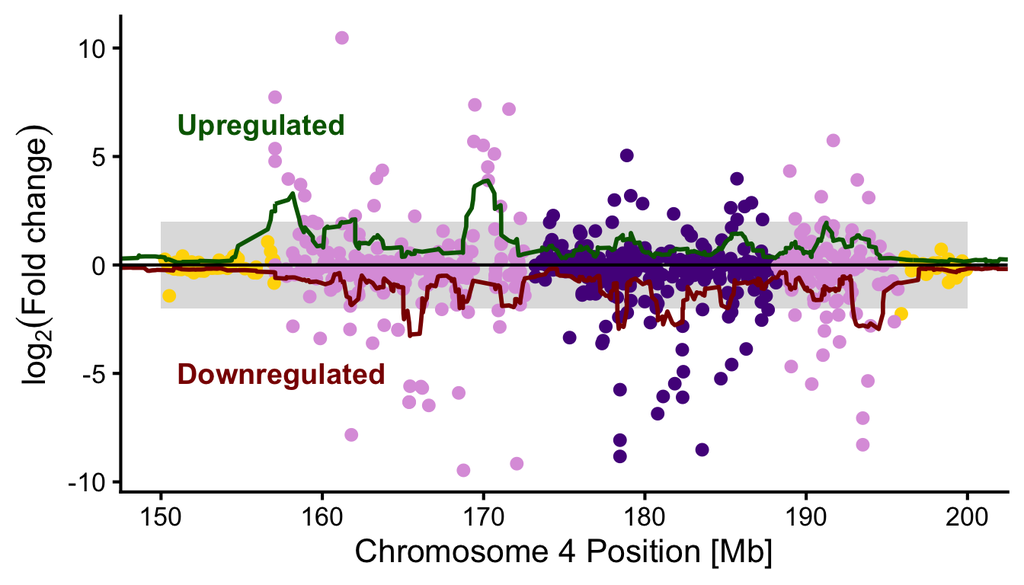

```r
pal <- c("purple4", "plum", "gold")
names(pal) <- c("inv4m", "flanking", "outside")

logFC_label <- expression(log[2]("Fold change"))

effects_df %>%
  filter(CHR == 4, BP > 150e6, BP < 200e6) %>%
  ggplot(aes(x = BP / 1e6, y = logFC, col = region)) +
  annotate("rect", xmin = 150, xmax = 200, ymin = -2, ymax = 2,
           alpha = 0.5, fill = "grey75") +
  geom_point() +
  scale_color_manual(values = pal) +
  coord_cartesian(xlim = c(150, 200)) +
  geom_line(
    data = to_plot_up,
    aes(x = BP / 1e6, y = foldchange), inherit.aes = FALSE,
    col = "darkgreen", linewidth = 1
  ) +
  geom_line(
    data = to_plot_down,
    aes(x = BP / 1e6, y = foldchange), inherit.aes = FALSE,
    col = "darkred", linewidth = 1
  ) +
  ylab(logFC_label) +
  xlab("Chromosome 4 Position [Mb]") +
  annotate("text", x = c(151, 151), y = c(6.5, -5),
           label = c("Upregulated", "Downregulated"),
           color = c("darkgreen", "darkred"),
           fontface = "bold", size = 5, hjust = 0) +
  geom_hline(yintercept = 0) +
  ggpubr::theme_classic2(base_size = 16) +
  theme(legend.position = "none")
```

# Boxplots: fold change and significance by region

## Setup

```r
regulation_order <- c("Downregulated", "Upregulated")
names(regulation_order) <- c("-1", "1")

to_plot <- effects_df %>%
  filter(CHR == 4) %>%
  mutate(
    regulation = regulation_order[as.character(sign(logFC))],
    zone = case_when(
      in_flanking & BP < 180e6 ~ "left",
      in_flanking & BP > 180e6 ~ "right",
      in_inv4m ~ "inv4m",
      .default = "outside"
    ),
    region = factor(region, levels = c("inv4m", "flanking", "outside"))
  )

to_plot$zone <- factor(to_plot$zone,
                       levels = c("left", "inv4m", "right", "outside"))
```

## Without splitting by direction

All expressed genes on chromosome 4, no up/down split.

### logFC by region (inv4m, flanking, outside)

```r
wilcox_region <- to_plot %>%
  rstatix::wilcox_test(logFC ~ region) %>%
  rstatix::adjust_pvalue(method = "BH") %>%
  rstatix::add_significance()

wilcox_region
```

```
## # A tibble: 3 × 9
##   .y.   group1   group2      n1    n2 statistic     p p.adj p.adj.signif
##   <chr> <chr>    <chr>    <int> <int>     <dbl> <dbl> <dbl> <chr>
## 1 logFC inv4m    flanking   253   355     43890 0.634 0.634 ns
## 2 logFC inv4m    outside    253  1850    217764 0.073 0.109 ns
## 3 logFC flanking outside    355  1850    303548 0.024 0.072 ns
```

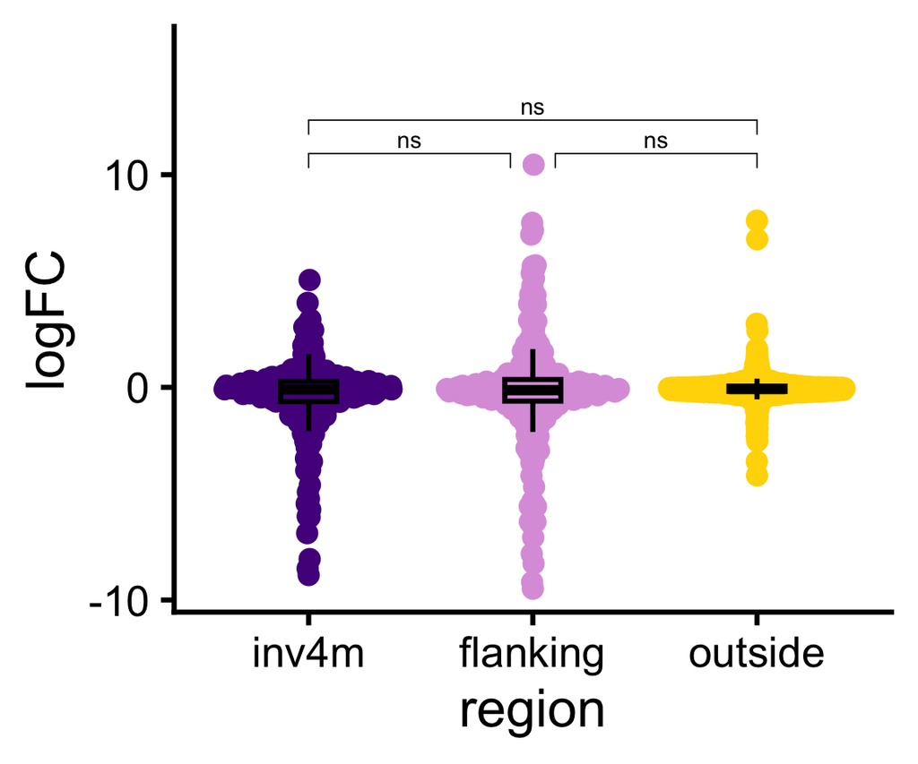

```r
# Manual bracket positions:
# inv4m=1, flanking=2, outside=3
# Level 1: inv4m-flanking and flanking-outside at same height
# Level 2: inv4m-outside spanning above both
ymax <- max(to_plot$logFC, na.rm = TRUE)
level1 <- ymax * 1.05
level2 <- ymax * 1.20

wilcox_region$xmin <- c(1, 1, 2.1)
wilcox_region$xmax <- c(1.9, 3, 3)
wilcox_region$y.position <- c(level1, level2, level1)

p_logfc_region <- to_plot %>%
  ggplot(aes(x = region, y = logFC, color = region)) +
  ggbeeswarm::geom_quasirandom() +
  geom_boxplot(width = 0.25, fill = NA, color = "black", outliers = FALSE) +
  scale_color_manual(values = pal) +
  scale_fill_manual(values = pal) +
  ggpubr::stat_pvalue_manual(wilcox_region, hide.ns = FALSE) +
  scale_y_continuous(expand = expansion(mult = c(0.05, 0.20))) +
  ggpubr::theme_classic2(base_size = 25) +
  theme(legend.position = "none")

p_logfc_region
```

```r
saveRDS(p_logfc_region, file.path(paths$intermediate, "panel_logfc_by_region.rds"))
```

### logFC by zone (left, inv4m, right, outside)

```r
wilcox_zone <- to_plot %>%
  rstatix::wilcox_test(logFC ~ zone, ref.group = "inv4m") %>%
  rstatix::adjust_pvalue(method = "BH") %>%
  rstatix::add_significance() %>%
  rstatix::add_xy_position(x = "zone", step.increase = 0.05)

wilcox_zone
```

```
## # A tibble: 3 × 13
##   .y.   group1 group2     n1    n2 statistic     p p.adj p.adj.signif y.position
##   <chr> <chr>  <chr>   <int> <int>     <dbl> <dbl> <dbl> <chr>             <dbl>
## 1 logFC inv4m  left      253   223     27437 0.606 0.814 ns                 10.7
## 2 logFC inv4m  right     253   132     16453 0.814 0.814 ns                 11.1
## 3 logFC inv4m  outside   253  1850    217764 0.073 0.219 ns                 11.6
## # ℹ 3 more variables: groups <named list>, xmin <dbl>, xmax <dbl>
```

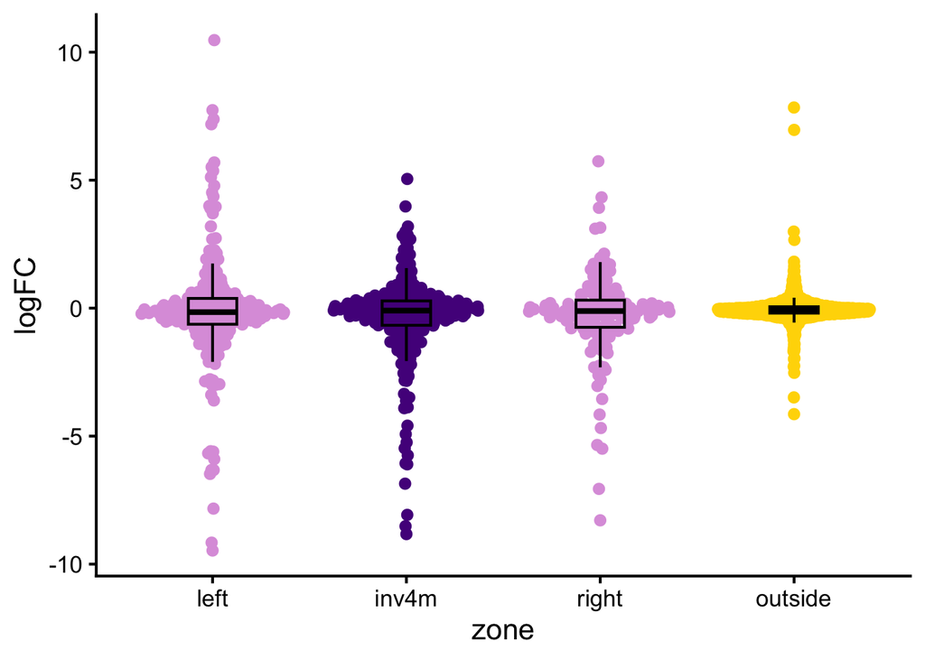

```r
to_plot %>%
  ggplot(aes(x = zone, y = logFC, color = region)) +
  ggbeeswarm::geom_quasirandom() +
  geom_boxplot(width = 0.25, fill = NA, color = "black", outliers = FALSE) +
  scale_color_manual(values = pal) +
  scale_fill_manual(values = pal) +
  ggpubr::stat_pvalue_manual(wilcox_zone, hide.ns = TRUE) +
  ggpubr::theme_classic2(base_size = 16) +
  theme(legend.position = "none")
```

### -log10(P) by region (inv4m, flanking, outside)

```r
wilcox_nlp_region <- to_plot %>%
  rstatix::wilcox_test(neglogP ~ region, ref.group = "inv4m") %>%
  rstatix::adjust_pvalue(method = "BH") %>%
  rstatix::add_significance() %>%
  rstatix::add_xy_position(x = "region", step.increase = 0.03)

wilcox_nlp_region
```

```
## # A tibble: 2 × 13
##   .y.     group1 group2      n1    n2 statistic        p    p.adj p.adj.signif
##   <chr>   <chr>  <chr>    <int> <int>     <dbl>    <dbl>    <dbl> <chr>
## 1 neglogP inv4m  flanking   253   355     43944 6.52e- 1 6.52e- 1 ns
## 2 neglogP inv4m  outside    253  1850    364895 2.64e-47 5.28e-47 ****
## # ℹ 4 more variables: y.position <dbl>, groups <named list>, xmin <dbl>,
## #   xmax <dbl>
```

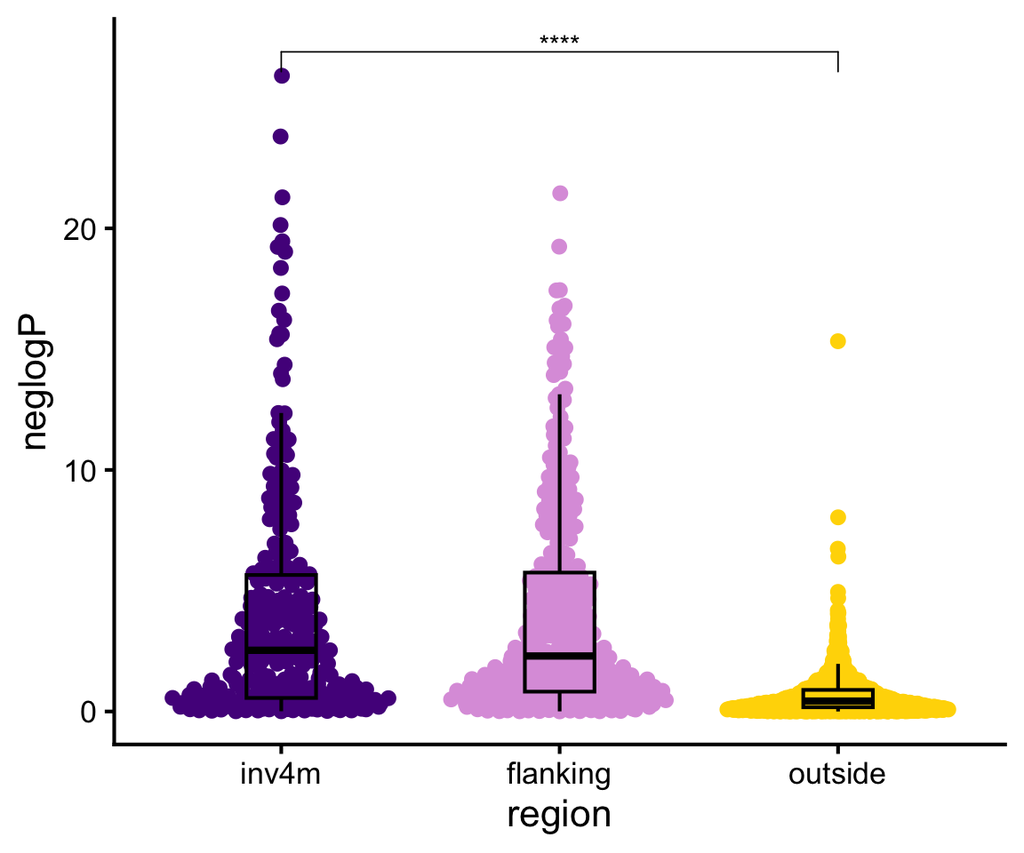

```r
to_plot %>%
  ggplot(aes(x = region, y = neglogP, color = region)) +
  ggbeeswarm::geom_quasirandom() +
  geom_boxplot(width = 0.25, fill = NA, color = "black", outliers = FALSE) +
  scale_color_manual(values = pal) +
  scale_fill_manual(values = pal) +
  ggpubr::stat_pvalue_manual(wilcox_nlp_region, hide.ns = TRUE) +
  ggpubr::theme_classic2(base_size = 16) +
  theme(legend.position = "none")
```

### -log10(P) by zone (left, inv4m, right, outside)

```r
wilcox_nlp_zone <- to_plot %>%
  rstatix::wilcox_test(neglogP ~ zone, ref.group = "inv4m") %>%
  rstatix::adjust_pvalue(method = "BH") %>%
  rstatix::add_significance() %>%
  rstatix::add_xy_position(x = "zone", step.increase = 0.03)

wilcox_nlp_zone
```

```
## # A tibble: 3 × 13
##   .y.     group1 group2     n1    n2 statistic        p    p.adj p.adj.signif
##   <chr>   <chr>  <chr>   <int> <int>     <dbl>    <dbl>    <dbl> <chr>
## 1 neglogP inv4m  left      253   223     27451 6.13e- 1 8.44e- 1 ns
## 2 neglogP inv4m  right     253   132     16493 8.44e- 1 8.44e- 1 ns
## 3 neglogP inv4m  outside   253  1850    364895 2.64e-47 7.92e-47 ****
## # ℹ 4 more variables: y.position <dbl>, groups <named list>, xmin <dbl>,
## #   xmax <dbl>
```

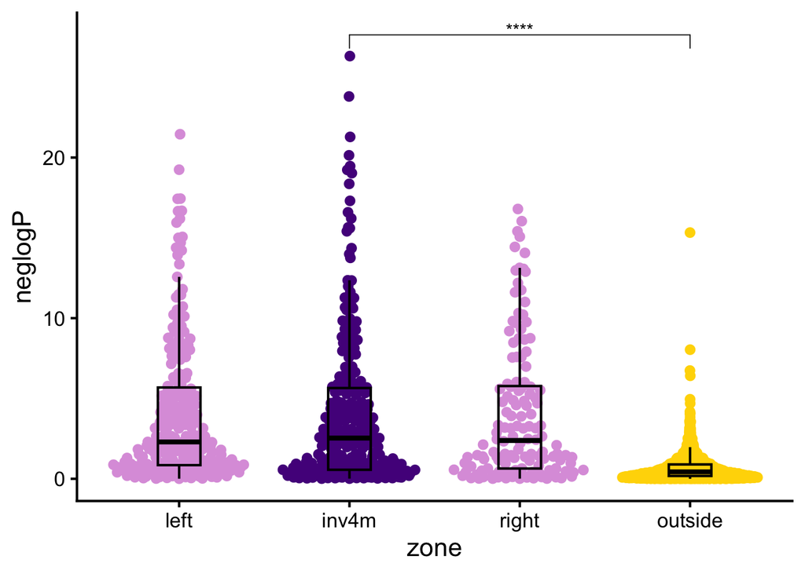

```r
to_plot %>%
  ggplot(aes(x = zone, y = neglogP, color = region)) +
  ggbeeswarm::geom_quasirandom() +
  geom_boxplot(width = 0.25, fill = NA, color = "black", outliers = FALSE) +
  scale_color_manual(values = pal) +
  scale_fill_manual(values = pal) +
  ggpubr::stat_pvalue_manual(wilcox_nlp_zone, hide.ns = TRUE) +
  ggpubr::theme_classic2(base_size = 16) +
  theme(legend.position = "none")
```

## Split by direction of regulation

Same panels but faceted by up/down.

### logFC by region

```r
wilcox_region_dir <- to_plot %>%
  group_by(regulation) %>%
  rstatix::wilcox_test(logFC ~ region, ref.group = "inv4m") %>%
  rstatix::adjust_pvalue(method = "BH") %>%
  rstatix::add_significance() %>%
  rstatix::add_xy_position(x = "region", step.increase = 0.05)

wilcox_region_dir
```

```
## # A tibble: 4 × 14
##   regulation    .y.   group1 group2      n1    n2 statistic        p    p.adj
##   <chr>         <chr> <chr>  <chr>    <int> <int>     <dbl>    <dbl>    <dbl>
## 1 Downregulated logFC inv4m  flanking   147   208     15225 9.48e- 1 9.48e- 1
## 2 Downregulated logFC inv4m  outside    147  1249     39296 6.87e-30 2.75e-29
## 3 Upregulated   logFC inv4m  flanking   106   147      6617 4.1 e- 2 5.47e- 2
## 4 Upregulated   logFC inv4m  outside    106   601     46074 2.22e-13 4.44e-13
## # ℹ 5 more variables: p.adj.signif <chr>, y.position <dbl>,
## #   groups <named list>, xmin <dbl>, xmax <dbl>
```

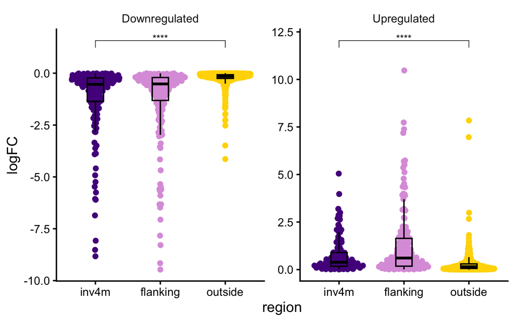

```r
to_plot %>%
  ggplot(aes(x = region, y = logFC, color = region)) +
  ggbeeswarm::geom_quasirandom() +
  geom_boxplot(width = 0.25, fill = NA, color = "black", outliers = FALSE) +
  scale_color_manual(values = pal) +
  scale_fill_manual(values = pal) +
  ggpubr::stat_pvalue_manual(wilcox_region_dir, hide.ns = TRUE) +
  facet_wrap(. ~ regulation, scales = "free_y") +
  ggpubr::theme_classic2(base_size = 16) +
  theme(legend.position = "none", strip.background = element_blank())
```

### logFC by zone

```r
wilcox_zone_dir <- to_plot %>%
  group_by(regulation) %>%
  rstatix::wilcox_test(logFC ~ zone, ref.group = "inv4m") %>%
  rstatix::adjust_pvalue(method = "BH") %>%
  rstatix::add_significance() %>%
  rstatix::add_xy_position(x = "zone", step.increase = 0.05)

wilcox_zone_dir
```

```
## # A tibble: 6 × 14
##   regulation    .y.   group1 group2     n1    n2 statistic        p    p.adj
##   <chr>         <chr> <chr>  <chr>   <int> <int>     <dbl>    <dbl>    <dbl>
## 1 Downregulated logFC inv4m  left      147   134      9636 7.55e- 1 8.54e- 1
## 2 Downregulated logFC inv4m  right     147    74      5589 7.39e- 1 8.54e- 1
## 3 Downregulated logFC inv4m  outside   147  1249     39296 6.87e-30 4.12e-29
## 4 Upregulated   logFC inv4m  left      106    89      3597 4   e- 3 8   e- 3
## 5 Upregulated   logFC inv4m  right     106    58      3020 8.54e- 1 8.54e- 1
## 6 Upregulated   logFC inv4m  outside   106   601     46074 2.22e-13 6.66e-13
## # ℹ 5 more variables: p.adj.signif <chr>, y.position <dbl>,
## #   groups <named list>, xmin <dbl>, xmax <dbl>
```

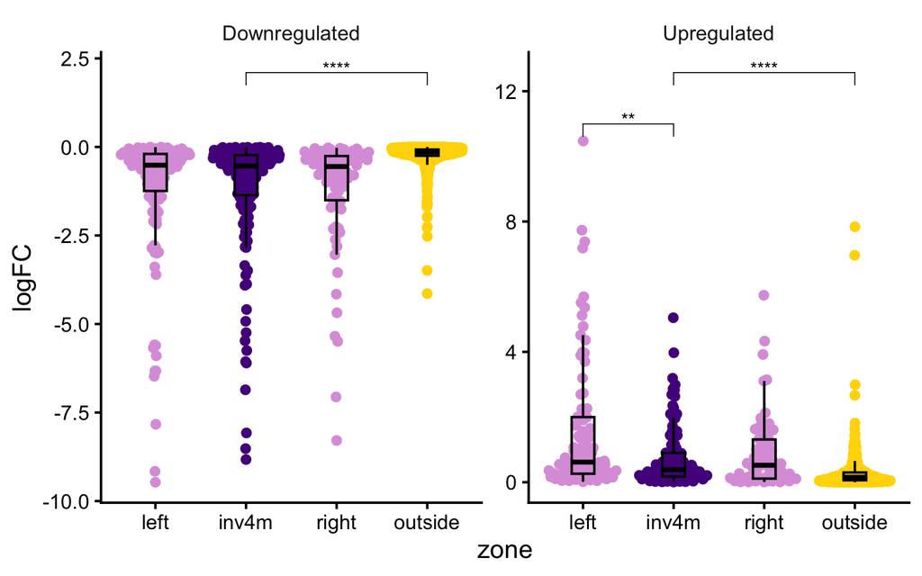

```r
to_plot %>%
  ggplot(aes(x = zone, y = logFC, color = region)) +
  ggbeeswarm::geom_quasirandom() +
  geom_boxplot(width = 0.25, fill = NA, color = "black", outliers = FALSE) +
  scale_color_manual(values = pal) +
  scale_fill_manual(values = pal) +
  ggpubr::stat_pvalue_manual(wilcox_zone_dir, hide.ns = TRUE) +
  facet_wrap(. ~ regulation, scales = "free_y") +
  ggpubr::theme_classic2(base_size = 16) +
  theme(legend.position = "none", strip.background = element_blank())
```

### -log10(P) by region

```r
wilcox_nlp_region_dir <- to_plot %>%
  group_by(regulation) %>%
  rstatix::wilcox_test(neglogP ~ region, ref.group = "inv4m") %>%
  rstatix::adjust_pvalue(method = "BH") %>%
  rstatix::add_significance() %>%
  rstatix::add_xy_position(x = "region", step.increase = 0.03)

wilcox_nlp_region_dir
```

```
## # A tibble: 4 × 14
##   regulation    .y.     group1 group2      n1    n2 statistic        p    p.adj
##   <chr>         <chr>   <chr>  <chr>    <int> <int>     <dbl>    <dbl>    <dbl>
## 1 Downregulated neglogP inv4m  flanking   147   208     15676 6.84e- 1 6.84e- 1
## 2 Downregulated neglogP inv4m  outside    147  1249    144021 1.39e-29 5.56e-29
## 3 Upregulated   neglogP inv4m  flanking   106   147      7161 2.73e- 1 3.64e- 1
## 4 Upregulated   neglogP inv4m  outside    106   601     50482 7.35e-22 1.47e-21
## # ℹ 5 more variables: p.adj.signif <chr>, y.position <dbl>,
## #   groups <named list>, xmin <dbl>, xmax <dbl>
```

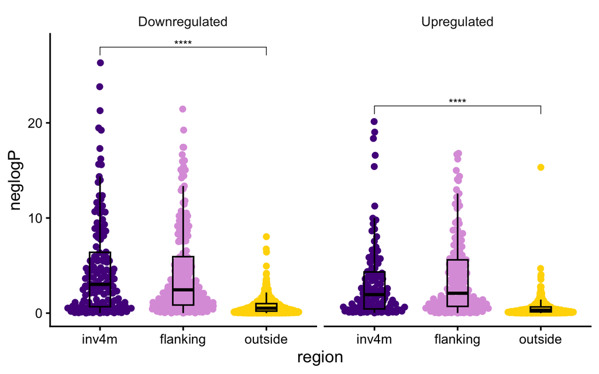

```r
to_plot %>%
  ggplot(aes(x = region, y = neglogP, color = region)) +
  ggbeeswarm::geom_quasirandom() +
  geom_boxplot(width = 0.25, fill = NA, color = "black", outliers = FALSE) +
  scale_color_manual(values = pal) +
  scale_fill_manual(values = pal) +
  ggpubr::stat_pvalue_manual(wilcox_nlp_region_dir, hide.ns = TRUE) +
  facet_wrap(. ~ regulation) +
  ggpubr::theme_classic2(base_size = 16) +
  theme(legend.position = "none", strip.background = element_blank())
```

### -log10(P) by zone

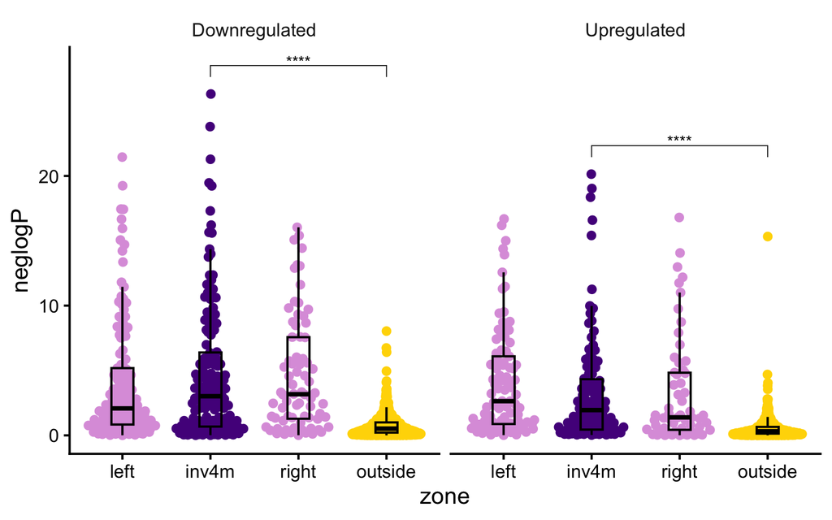

```r
wilcox_nlp_zone_dir <- to_plot %>%
  group_by(regulation) %>%
  rstatix::wilcox_test(neglogP ~ zone, ref.group = "inv4m") %>%
  rstatix::adjust_pvalue(method = "BH") %>%
  rstatix::add_significance() %>%
  rstatix::add_xy_position(x = "zone", step.increase = 0.03)

to_plot %>%
  ggplot(aes(x = zone, y = neglogP, color = region)) +
  ggbeeswarm::geom_quasirandom() +
  geom_boxplot(width = 0.25, fill = NA, color = "black", outliers = FALSE) +
  scale_color_manual(values = pal) +
  scale_fill_manual(values = pal) +
  ggpubr::stat_pvalue_manual(wilcox_nlp_zone_dir, hide.ns = TRUE) +
  facet_wrap(. ~ regulation) +
  ggpubr::theme_classic2(base_size = 16) +
  theme(legend.position = "none", strip.background = element_blank())
```

# Summary

```r
with(effects_df %>% filter(is_significant), table(region))
```

```
## region
## flanking    inv4m  outside
##      158      114      193
```